# Information directed sampling for stochastic root finding

Sergio Rodriguez

July 26, 2015

### Example: American put option

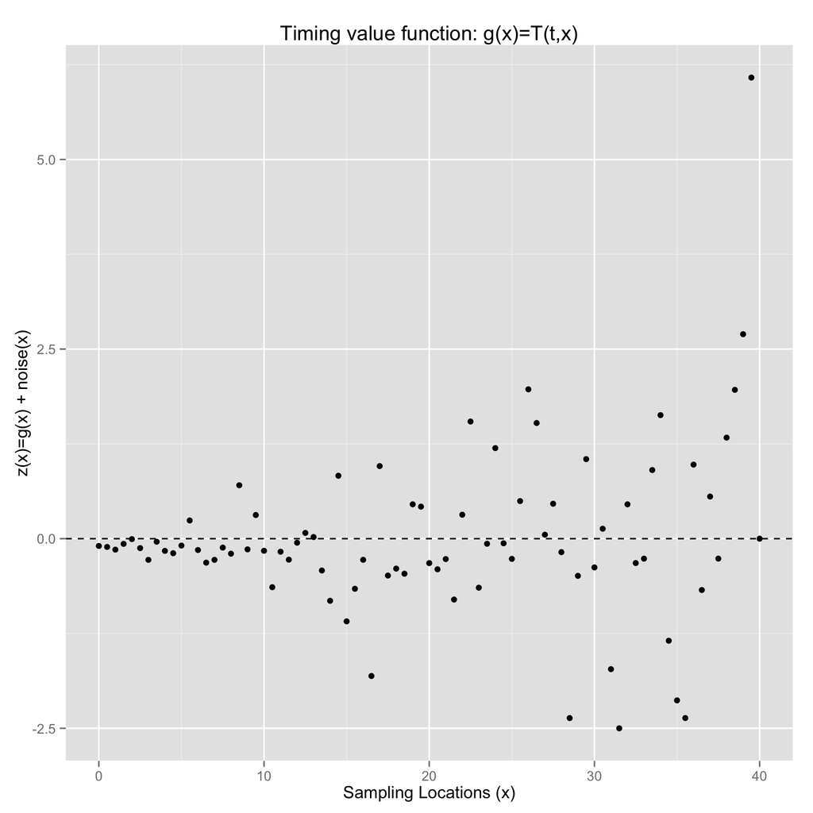

### Probability of correct oracle response estimation

The probability of correct oracle answers $p(x)$ is estimated off-line and a priori. To do so, I use a grid of 100 equidistant points over $(0,40)$ such that 20 function evaluations are made at each sampling location.

#### Logistic regression over sampling locations

Let $s(x) = \mathbb{P}[Y(x)=-1]$ be the probability of oracle indicating a right move when sampling at $x$ (the underlying funtion $g$ is increasing). In order to estimate $s(x)$ we consider the model:

$\log(\frac{s(x)}{1-s(x)}) \equiv \mbox{logit}(s(x)) = \beta_{0} + \beta_{1}x + \beta_{2}x^{2} + \beta_{2}x^{3}$

Given the estimate of $s(x)$, the probability of correct oracle responses $p(x)$ is estimated by:

$p(x) = \left\{ \begin{array}{cc} s(x) & \mbox{if $s(x)>1/2$} \\ 1-s(x) & \mbox{if $s(x)<=1/2$} \end{array} \right.$

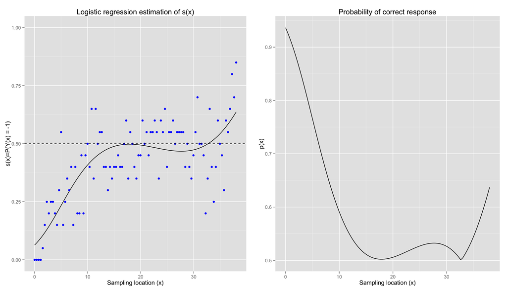

### Probabilistic Bisection for Stochastic Root Finding

- Six sampling heuristics are implemented:
1. Uniformly over $[0,40]$
2. Uniformly over the quantiles of $f_{n}$
3. Median of $f_{n}$
4. Maximizer of mutual information between root location and oracle replies
5. Quantile with highest mutual information (20-80 are chosen)
6. Systematically alternate at the 20-80 quantiles

For now I only ran one single MonteCarlo iteration for T=1000 total wall-clock interation using the following arbitrarily chosen batch-sizes: $K \in \{1,5,25,50\}$, resulting in $N = 1000,200,40,20$ macro-iterations respectively. MC=1 iteration is about 1.8 min. Considerations about the number of MC iteration should be made.

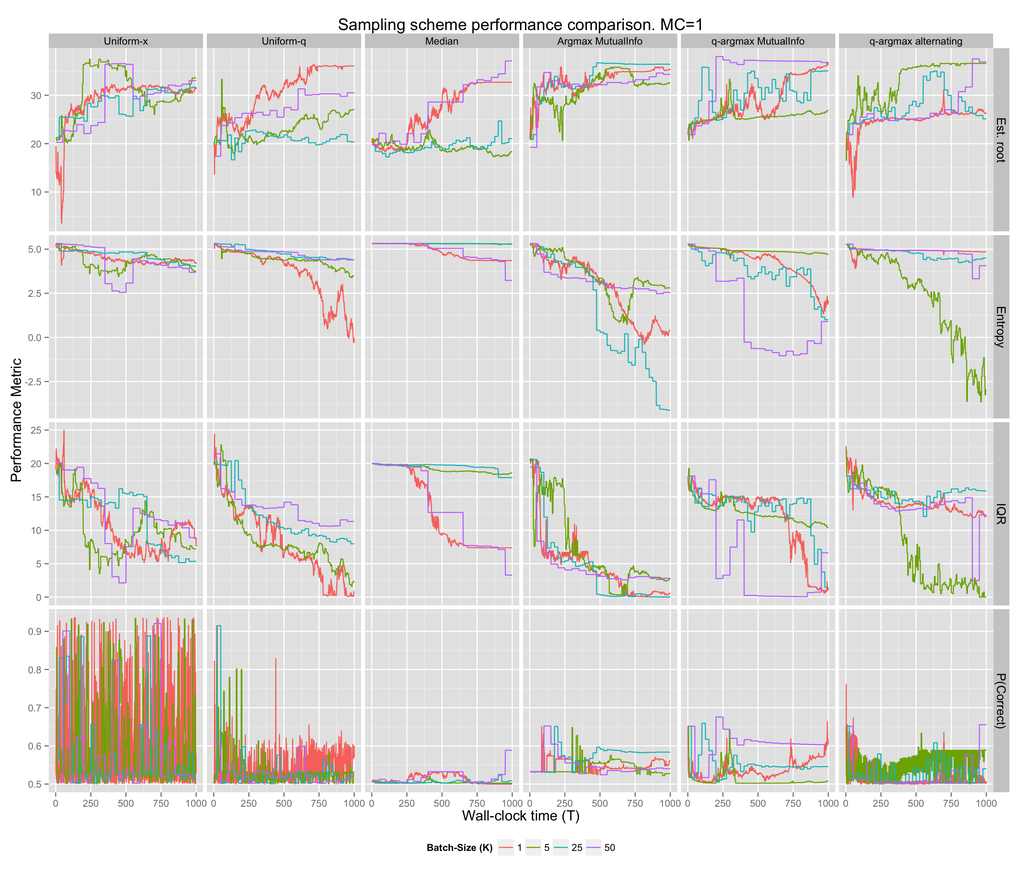

| SamplingScheme | PerformanceMetric | Oracle.1 | Oracle.5 | Oracle.25 | Oracle.50 |
| --- | --- | --- | --- | --- | --- |
| Uniform-x | estRoot.overall | 31.5593 | 33.5784 | 31.6392 | 33.0525 |
| Uniform-x | entropy.overall | 4.1860 | 3.7519 | 4.0370 | 3.6879 |
| Uniform-x | iqr.overall | 7.5616 | 7.2264 | 5.3607 | 8.9015 |
| Uniform-x | p.effective | 0.5309 | 0.5021 | 0.5134 | 0.5176 |
| Uniform-q | estRoot.overall | 36.0897 | 27.0563 | 20.3637 | 30.5183 |
| Uniform-q | entropy.overall | -0.0212 | 3.4892 | 4.4040 | 4.3870 |
| Uniform-q | iqr.overall | 0.8675 | 2.4214 | 7.9800 | 11.3282 |
| Uniform-q | p.effective | 0.5704 | 0.5321 | 0.5283 | 0.5195 |
| Median | estRoot.overall | 32.7009 | 18.3837 | 21.0427 | 37.1084 |
| Median | entropy.overall | 4.3545 | 5.2995 | 5.2811 | 3.2283 |
| Median | iqr.overall | 7.3867 | 18.5737 | 17.8795 | 3.2936 |
| Median | p.effective | 0.5000 | 0.5024 | 0.5087 | 0.5886 |
| Argmax MutualInfo | estRoot.overall | 35.4251 | 32.6293 | 36.4362 | 34.3185 |
| Argmax MutualInfo | entropy.overall | 0.3915 | 2.8013 | -4.1236 | 2.5455 |
| Argmax MutualInfo | iqr.overall | 0.5832 | 2.7070 | 0.0170 | 2.8203 |
| Argmax MutualInfo | p.effective | 0.5611 | 0.5280 | 0.5836 | 0.5401 |
| q-argmax MutualInfo | estRoot.overall | 36.7338 | 26.8670 | 35.0385 | 36.7825 |
| q-argmax MutualInfo | entropy.overall | 2.0590 | 4.7009 | 1.0041 | 0.9002 |
| q-argmax MutualInfo | iqr.overall | 1.3667 | 10.3980 | 1.4554 | 6.6433 |
| q-argmax MutualInfo | p.effective | 0.6125 | 0.5084 | 0.5459 | 0.6027 |
| q-argmax alternating | estRoot.overall | 26.2154 | 36.5917 | 25.1186 | 36.8814 |
| q-argmax alternating | entropy.overall | 4.8526 | -2.9579 | 4.5009 | 4.0645 |
| q-argmax alternating | iqr.overall | 12.1199 | 0.0225 | 15.9047 | 12.3209 |
| q-argmax alternating | p.effective | 0.5074 | 0.5890 | 0.5399 | 0.6552 |

### Sampling scheme accuracy

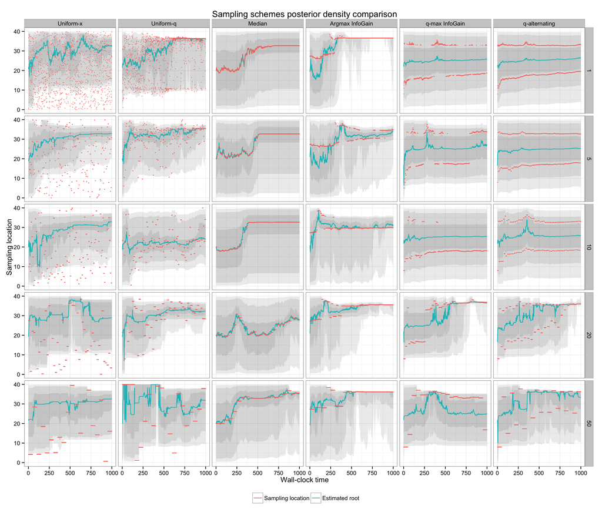